# R Notebook

# Filtering data with different thresholds:

Per meting on 9-6-2018, filtering the community dataset to a subset of species may greatly improve the relevance + significance of our result.

Key “levers” to manipulate:

- Normalization of cover values - dividing matrix values by row total
  - Maximum (total) cover = 1
- Mean cover in control
  - Mean cover in control plot over the observed sampling period
- Persistence in control
  - Number of observations of a species in control over the observed sampling period
- Present in year 0 for control and at least one nutrient treatment
  - Observations in initial year that may influence detrending

And correlations between between.

```
Source: local data table [6 x 19]

# A tibble: 6 x 19
  site_code block trt    plot  year site_name subplot year_trt Family Taxon  live local_provenance local_lifeform
  <fct>     <int> <chr> <int> <int> <chr>     <chr>      <int> <chr>  <chr> <int> <chr>            <chr>
1 azi.cn        1 Cont~     1  2007 Azi       C              0 Poace~ AGRO~     1 NAT              HERB
2 azi.cn        1 Cont~     1  2007 Azi       C              0 Amary~ ALLI~     1 NAT              HERB
3 azi.cn        1 Cont~     1  2007 Azi       C              0 Ranun~ ANEM~     1 NAT              HERB
4 azi.cn        1 Cont~     1  2007 Azi       C              0 Ranun~ ANEM~     1 NAT              HERB
5 azi.cn        1 Cont~     1  2007 Azi       C              0 Ranun~ ANEM~     1 NAT              HERB
6 azi.cn        1 Cont~     1  2007 Azi       C              0 Compo~ ARTE~     1 NAT              HERB
# ... with 6 more variables: local_lifespan <chr>, functional_group <chr>, N_fixer <chr>, ps_path <chr>,
#   max_cover <dbl>, region <chr>
```

# Tuning function:

```r
tuneR <- function(covdata, # Cover data
                  selected.trts = c("Control", "N", "P", "K", "Fence", "NPK", "NPK + Fence"), # Treatments to include
                  normalize = TRUE, # Normalize or not? Logical
                  sigdig = 2 # Number of significant digits for rounding
){

  # If deciding to normalize data
  if(normalize == TRUE){

      # For all site x block x plot x year_trt combinations
    coversums <- covdata %>% group_by(site_code, block, plot, year_trt) %>%

      # Create a new column of total cover and join to dataset
      summarise(plottotal = sum(na.omit(max_cover)))
    # Setting new cover data with normalized cover
    covdata <- left_join(covdata, coversums) %>%

      # Reassign max_cover as normalized cover value
      mutate(max_cover = round(max_cover / plottotal, sigdig)) %>%

      # Remove the total cover value
      select(-plottotal)

    if(max(covdata$max_cover) > 1){
      stop(paste("Error - Max cover value not less than one in sites",
                 unique(covdata$site_code[covdata$max_cover > 1])))
    }
  }

  # General observation table
  obs.per.plot = data.frame(covdata) %>%
    filter(trt %in% selected.trts) %>%
    group_by(site_code, block) %>%
    summarise(nyears = length(unique(year)),
              firstyear = min(year),
              lastyear = max(year))

  # Frequency of species observations and mean cover
  summarise_obs <- function(x){

    output = data.frame(totalobs = nrow(x))
    counter = 1

    for(i in unique(selected.trts)){

      counter = counter + 1
      output = bind_cols(output, new = sum(x$trt == i))
      colnames(output)[counter] = paste("tot_obs", i, sep = "")

      counter = counter + 1
      output = bind_cols(output, new = mean(na.omit(x$max_cover[x$trt == i])))
      colnames(output)[counter] = paste("mean_cov", i, sep = "")
    }

    return(output)
  }

  specobs = data.frame(covdata) %>%
      filter(trt %in% selected.trts) %>%
      group_by(site_code, block, Taxon) %>%
      do(summarise_obs(.))

  # Presence in the first year of sampling
  summarise_yearzero <- function(x){

    output = data.frame(total_pret_obs = nrow(x))
    counter = 1

    for(i in unique(selected.trts)){

      counter = counter + 1
      output = bind_cols(output, new = sum(x$trt == i))
      colnames(output)[counter] = paste("pret_obs", i, sep = "")

      counter = counter + 1
      newval = x$max_cover[x$trt == i]
      if(length(newval) == 0){newval = 0}
      output = bind_cols(output, new = newval)
      colnames(output)[counter] = paste("pret_cov", i, sep = "")
    }

    return(output)
  }

  trtcov <- data.frame(covdata) %>%
    filter(trt %in% selected.trts) %>%
    filter(year_trt == 0) %>%
    group_by(site_code, block, Taxon) %>%
    do(summarise_yearzero(.))
  # Binding all values together into a single dataset

  fulloutput = inner_join(obs.per.plot, specobs, by = c("site_code", "block"))
  fulloutput = left_join(fulloutput, trtcov, by = c("site_code", "block", "Taxon"))
  fulloutput = fulloutput %>% replace(., is.na(.), 0) %>% ungroup()

  return(fulloutput)
}
tuningtable <- tuneR(cover.long)
```

[output not shown]

```r
write.csv(x = tuningtable, "../data/tuningtable_normalized.csv")
head(tuningtable)
```

```
# A tibble: 6 x 36
  site_code block nyears firstyear lastyear Taxon totalobs tot_obsControl mean_covControl tot_obsN mean_covN tot_obsP
  <fct>     <int>  <int>     <dbl>    <dbl> <chr>    <int>          <int>           <dbl>    <int>     <dbl>    <int>
1 azi.cn        1      5      2007     2012 ACON~        1              0           0            0   0              0
2 azi.cn        1      5      2007     2012 AGRO~       24              5           0.068        4   0.1            4
3 azi.cn        1      5      2007     2012 ALLI~       20              5           0.004        3   0.00667        4
4 azi.cn        1      5      2007     2012 ANAP~        2              0           0            0   0              0
5 azi.cn        1      5      2007     2012 ANAP~        1              0           0            0   0              1
6 azi.cn        1      5      2007     2012 ANEM~       29              5           0.024        4   0.02           5
# ... with 24 more variables: mean_covP <dbl>, tot_obsK <int>, mean_covK <dbl>, tot_obsFence <int>, mean_covFence <dbl>,
#   tot_obsNPK <int>, mean_covNPK <dbl>, `tot_obsNPK + Fence` <int>, `mean_covNPK + Fence` <dbl>, total_pret_obs <dbl>,
#   pret_obsControl <dbl>, pret_covControl <dbl>, pret_obsN <dbl>, pret_covN <dbl>, pret_obsP <dbl>, pret_covP <dbl>,
#   pret_obsK <dbl>, pret_covK <dbl>, pret_obsFence <dbl>, pret_covFence <dbl>, pret_obsNPK <dbl>, pret_covNPK <dbl>,
#   `pret_obsNPK + Fence` <dbl>, `pret_covNPK + Fence` <dbl>
```

# Column Names in TuningTable

New columns:

**Plot level**  
* nyears - Number of years of observations (plot)  
* firstyear - First year of observation (plot)  
* lastyear - Last year of observation (plot)

**Taxon level**  
* Taxon - Taxon name  
* totalobs - Total number of observations in block, over time  
* tot_obsControl - Total number of observations in control plot  
* mean_covControl - Mean cover in control plot, all years  
* tot_obsN - Total number of observations in +N plot  
* mean_covN - Mean cover in +N plot, all years  
* tot_obsP - Total number of observations in +P plot  
* mean_covP - Mean cover in control +P, all years  
* tot_obsK - Total number of observations in +K plot  
* mean_covK - Mean cover in +K plot, all years  
* tot_obsFence - Total number of observations in +Fence plot  
* mean_covFence - Mean cover in +Fence plot, all years  
* tot_obsNPK - Total number of observations in +NPK plot  
* mean_covNPK - Mean cover in +NPK plot, all years  
* tot_obsNPK + Fence - Total number of observations in +NPK + Fence plot  
* mean_covNPK + Fence - Mean cover in +NPK + Fence plot, all years

**Pretreatment, Taxon level**  
* total_pret_obs - Total number of observations in block, first year  
* pret_obsControl - Observation in control plot, first year (1/0)  
* pret_covControl - Cover in control plot, first year  
* pret_obsN - Observation in +N plot, first year (1/0)  
* pret_covN - Cover in +N plot, first year  
* pret_obsP - Observation in +P plot, first year (1/0)  
* pret_covP - Cover in +P plot, first year  
* pret_obsK - Observation in +K plot, first year (1/0)  
* pret_covK - Cover in +K plot, first year  
* pret_obsFence - Observation in +Fence plot, first year (1/0)  
* pret_covFence - Cover in +Fence plot, first year  
* pret_obsNPK - Observation in +NPK plot, first year (1/0)  
* pret_covNPK - Cover in +NPK plot, first year  
* pret_obsNPK + Fence - Observation in +NPK + Fence plot, first year (1/0)  
* pret_covNPK + Fence - Cover in +NPK + Fence plot, first year

**As an aside, some of the sites don’t seem to be behaving well:** The unique years recorded does not always seem to equal the first year subtracted from the last year, + 1. Is this the result of years where no live species are recorded in a plot?

**Offending sites:**

```
[1] "azi.cn"    "barta.us"  "hogone.us" "pinj.au"
```

# Correlations among measures:

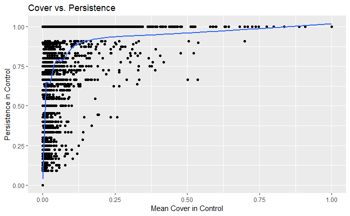

```r
badsites = as.character(unique(tuningtable$site_code[tuningtable$totalobs > tuningtable$nyears * 7]))
tuningtable = tuningtable %>% filter(! site_code %in% badsites)
# Mean control cover
tuningtable %>% ggplot(aes(x = mean_covControl * (tot_obsControl / (tuningtable$lastyear - tuningtable$firstyear + 1)),
                           y = tot_obsControl / (tuningtable$lastyear - tuningtable$firstyear + 1))) +
  geom_point() +
  stat_smooth(se = FALSE) +
  ylab("Persistence in Control") +
  xlab("Mean Cover in Control") +
  ggtitle("Cover vs. Persistence")
```

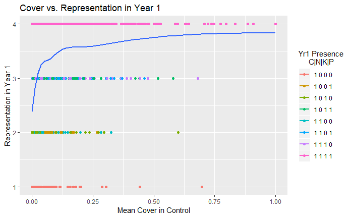

```r
# Persistence in control
tuningtable %>% filter(pret_obsControl == 1) %>%
  ggplot(aes(x = mean_covControl * (tot_obsControl / (lastyear - firstyear + 1)),
                           y = pret_obsControl + pret_obsN + pret_obsK + pret_obsP,
                           color = paste(pret_obsControl, pret_obsN, pret_obsK, pret_obsP))) +
  geom_point() +
  stat_smooth(se = FALSE, aes(color = NULL)) +
  ylab("Representation in Year 1") +
  xlab("Mean Cover in Control") +
  ggtitle("Cover vs. Representation in Year 1") +
  guides(color=guide_legend(title="Yr1 Presence \n     C|N|K|P"))
```

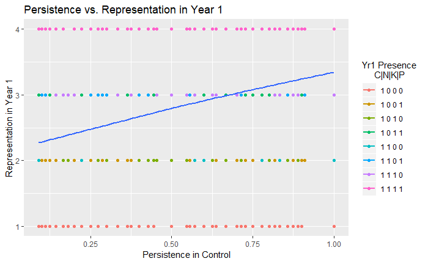

```r
# Presence in year 0 + at least 1 nutrient addition treatment
tuningtable %>% filter(pret_obsControl == 1) %>%
  ggplot(aes(x = tot_obsControl / (lastyear - firstyear + 1),
             y = pret_obsControl + pret_obsN + pret_obsK + pret_obsP,
             color = paste(pret_obsControl, pret_obsN, pret_obsK, pret_obsP))) +
  geom_point() +
  stat_smooth(se = FALSE, aes(color = NULL)) +
  ylab("Representation in Year 1") +
  xlab("Persistence in Control") +
  ggtitle("Persistence vs. Representation in Year 1") +
  guides(color=guide_legend(title="Yr1 Presence \n     C|N|K|P"))
```

# LRR Sensitivity to Filtering Approaches

```r
# Normalizing cover data:
# For all site x block x plot x year_trt combinations
coversums <- cover.long %>% group_by(site_code, block, plot, year_trt) %>%

  # Create a new column of total cover and join to dataset
  summarise(plottotal = sum(na.omit(max_cover)))
# Setting new cover data with normalized cover
cover.long <- left_join(cover.long, coversums) %>%

  # Reassign max_cover as normalized cover value
  mutate(max_cover = round(max_cover / plottotal, sigdig)) %>%

  # Remove the total cover value
  select(-plottotal)
if(max(cover.long$max_cover) > 1){
  stop(paste("Error - Max cover value not less than one in sites",
             unique(cover.long$site_code[cover.long$max_cover > 1])))
}
#Clean out unknowns, non-vascular plants
sps <- unique(cover.long$Taxon)
unwanted.sps <- sps[c(grep('UNKNOWN',sps),grep('BRYOPHYTE',sps),grep('LICHEN',sps))]
cover.long <- cover.long[!(Taxon %in% unwanted.sps | local_lifeform == 'MOSS' | functional_group == 'BRYOPHYTE')]
cover.long[functional_group=='GRAMINOID',functional_group := 'GRASS']
```

```
Source: local data table [144,621 x 19]
Groups:

# A tibble: 144,621 x 19
   site_code block  plot year_trt trt    year site_name subplot Family Taxon  live local_provenance local_lifeform
   <fct>     <int> <int>    <int> <chr> <int> <chr>     <chr>   <chr>  <chr> <int> <chr>            <chr>
 1 azi.cn        1     1        0 Cont~  2007 Azi       C       Poace~ AGRO~     1 NAT              HERB
 2 azi.cn        1     1        0 Cont~  2007 Azi       C       Amary~ ALLI~     1 NAT              HERB
 3 azi.cn        1     1        0 Cont~  2007 Azi       C       Ranun~ ANEM~     1 NAT              HERB
 4 azi.cn        1     1        0 Cont~  2007 Azi       C       Ranun~ ANEM~     1 NAT              HERB
 5 azi.cn        1     1        0 Cont~  2007 Azi       C       Ranun~ ANEM~     1 NAT              HERB
 6 azi.cn        1     1        0 Cont~  2007 Azi       C       Compo~ ARTE~     1 NAT              HERB
 7 azi.cn        1     1        0 Cont~  2007 Azi       C       Fabac~ ASTR~     1 NAT              HERB
 8 azi.cn        1     1        0 Cont~  2007 Azi       C       Caryo~ CERA~     1 NAT              HERB
 9 azi.cn        1     1        0 Cont~  2007 Azi       C       Poace~ DESC~     1 NAT              HERB
10 azi.cn        1     1        0 Cont~  2007 Azi       C       Poace~ ELYM~     1 NAT              HERB
# ... with 144,611 more rows, and 6 more variables: local_lifespan <chr>, functional_group <chr>, N_fixer <chr>,
#   ps_path <chr>, max_cover <dbl>, region <chr>
```

```r
rm(sps,unwanted.sps)
#Choose plots with at least 3 years of data
## This takes care of a few sites that have strange plot configurations,
## like sgs.us
site.plots.keep <- cover.long %>% group_by(site_code,block,plot,trt) %>%
  summarise(yrs.data = length(unique(year))) %>% filter(yrs.data>=3)
## Some sites have multiple control plots in a block.
## Choosing only the lowest numbered plot belong to a treatment in each block.
site.plots.keep <- left_join(site.plots.keep,
                             site.plots.keep %>% group_by(site_code,block,trt) %>%
                               summarize(min.plot = min(plot))) %>%
  filter(plot==min.plot) %>% select(-min.plot,-yrs.data)
cover.long <- left_join(site.plots.keep,cover.long)
cover.long <- droplevels(cover.long) #cover.long$site_code <- factor(cover.long$site_code)
rm(site.plots.keep)
# cast long into wide
cover.wide <- dcast(cover.long,site_code+year+block+plot+trt ~ Taxon,value.var='max_cover', fun.aggregate = sum,drop=T,fill=0)
# Adding in additional info ----------------------------------------------------
siteinfo <- biomass_data[site_code %in% sites.long, .(`site_code`,`site_name`,`continent`,`region`,`first_nutrient_year`,`site_richness`)] %>% distinct()
spsinfo <- select(data.frame(cover.long),site_code,Family:ps_path,-live) %>% distinct()
#Summarizing some information about the species
#Max cover reached in a plot in that site, CV of cover
# coeflist.site <- left_join(coeflist.site,cover.long %>% group_by(site_code, Family, Taxon) %>% summarize(max.cover = max(max_cover), cv.cover=sd(max_cover)/mean(max_cover)))
# Independent measure of N,P and K response following EL 2013 ----------------------------------
# Intermediate data products
### dat2 - cover data from which LRRs are being calculated
### dat3 - baseline year data for each species-plot
### dat4 - LRR for each species plot relative to baseline
### dat5 - LRR of nut effect after detrending control
#Species selection -    "only those species recorded at least once either pre or
# post treatment in the nutrient treatment plot within a block"
# keep a species-site-block-trt only if has an observation in the Nut treated plots, at any point of time
obs.keep <- cover.long[trt != 'Control'] %>% group_by(site_code,Taxon,block,trt) %>%
  summarize(num.yrs = length(unique(year))) %>% mutate(iden = paste0(site_code,Taxon,block))
# Use at the end of the procedure to only select the ones we want
dat <- cover.long[,iden := paste0(site_code,Taxon,block)]
dat <- dat[iden %in% unique(obs.keep$iden)]
obs.keep[,iden:= NULL]
```

```
Source: local data table [36,477 x 5]
Groups: site_code, Taxon

# A tibble: 36,477 x 5
   site_code Taxon                  block trt   num.yrs
   <fct>     <chr>                  <int> <chr>   <int>
 1 azi.cn    AGROSTIS STOLONIFERA       1 Fence       4
 2 azi.cn    ANEMONE OBTUSILOBA         1 Fence       5
 3 azi.cn    ANEMONE RIVULARIS          1 Fence       5
 4 azi.cn    ANEMONE TRULLIFOLIA        1 Fence       3
 5 azi.cn    ARENARIA SERPYLLIFOLIA     1 Fence       1
 6 azi.cn    ARTEMISIA MONGOLICA        1 Fence       1
 7 azi.cn    ASTRAGALUS POLYCLADUS      1 Fence       5
 8 azi.cn    CERASTIUM ARVENSE          1 Fence       4
 9 azi.cn    DESCHAMPSIA CESPITOSA      1 Fence       3
10 azi.cn    ELYMUS NUTANS              1 Fence       5
# ... with 36,467 more rows
```

```r
#convert to wide, but only at the site-block scale, to avoid too many zeros
# Add minimum observed percent cover (0.01) to all values - to the wide table
# Convert back to long
dat2 <- data.table()
#i='cdcr.us' ; j = 1
for (i in unique(dat$site_code)) {
  subdat <- dat[site_code==i]
  for (j in unique(subdat$block)) {
    subdat2 <- subdat[block==j]
    dat2.wide <- dcast(subdat2,site_code+year+year_trt+block+plot+trt ~ Taxon,value.var='max_cover', fun.aggregate = sum,drop=T,fill=0)
    #Now add 0.01 to all values
    dat2.wide[,7:ncol(dat2.wide)] <- dat2.wide[,7:ncol(dat2.wide)] + .01
    dat2.long <- melt(dat2.wide,id.vars=c(1:6),variable.name='Taxon',value.name='max_cover')
    dat2 <- bind_rows(dat2,dat2.long)
  }
}
rm(dat2.long,dat2.wide,i,j,subdat,subdat2)
# Calculate LRR of each year relative to pretreatment year ----------------
#add in cover of pretrt year for each species-plot combination
dat3 <- dat2 %>% group_by(site_code,plot,Taxon) %>% filter(year_trt == min(year_trt))
dat3 <- dat3[,.(`site_code`,`plot`,`Taxon`,`year_trt`,`max_cover`)] %>% rename(base_year=year_trt,cover_base=max_cover)
#dat3 <- dat3[,.(`site_code`,`plot`,`Taxon`,`base_year`=year_trt,`cover_base`=max_cover)]
#    select(site_code,plot,Taxon,`base_year`=year_trt,`cover_base`=max_cover)
# sier.us, sgs.us and hopl.us show some species as having their min(year_trt) measurement in y1
# saline.us and saana.fi are missing pretrt year in the cover dataset
#table(dat1[site_code=='hopl.us']$plot,dat1[site_code=='hopl.us']$year)
dat4 <- left_join(dat2,dat3)
dat4 <- dat4[year_trt != base_year] #remove the base year
dat4[,LRRt := log2(max_cover/cover_base)] ;
```

```
Source: local data table [512,368 x 11]

# A tibble: 512,368 x 11
   site_code  plot Taxon                 year year_trt block trt     max_cover base_year cover_base   LRRt
   <fct>     <int> <chr>                <int>    <int> <int> <chr>       <dbl>     <int>      <dbl>  <dbl>
 1 azi.cn        1 ACONITUM SP.          2008        1     1 Control      0.01         0     0.01    0
 2 azi.cn        1 ACONITUM SP.          2009        2     1 Control      0.01         0     0.01    0
 3 azi.cn        1 ACONITUM SP.          2011        4     1 Control      0.01         0     0.01    0
 4 azi.cn        1 ACONITUM SP.          2012        5     1 Control      0.01         0     0.01    0
 5 azi.cn        1 AGROSTIS STOLONIFERA  2008        1     1 Control      0.12         0     0.0700  0.778
 6 azi.cn        1 AGROSTIS STOLONIFERA  2009        2     1 Control      0.13         0     0.0700  0.893
 7 azi.cn        1 AGROSTIS STOLONIFERA  2011        4     1 Control      0.04         0     0.0700 -0.807
 8 azi.cn        1 AGROSTIS STOLONIFERA  2012        5     1 Control      0.03         0     0.0700 -1.22
 9 azi.cn        1 AGROSTIS VINEALIS     2008        1     1 Control      0.01         0     0.01    0
10 azi.cn        1 AGROSTIS VINEALIS     2009        2     1 Control      0.01         0     0.01    0
# ... with 512,358 more rows
```

```r
#Chose log2 in order for the coefficients to be interpretable
# Detrend from the control ------------------------------------------------
#add a column of control for each species-block in a year
dat5 <- left_join(dat4[trt!='Control'],
                  select(dat4[trt=='Control'],site_code,Taxon,year,year_trt,block,plot_cont=plot,cover_cont=max_cover,cover.base_cont=cover_base,LRRcont_yt=LRRt))
dat5 <- rename(dat5,LRRnut_yt=LRRt,plot_nut=plot,cover_nut=max_cover,cover.base_nut=cover_base)
dat5[,LRR_nut := LRRnut_yt-LRRcont_yt]
```

```
Source: local data table [459,563 x 16]

# A tibble: 459,563 x 16
   site_code Taxon  year year_trt block plot_nut trt   cover_nut base_year cover.base_nut LRRnut_yt plot_cont cover_cont
   <fct>     <chr> <int>    <int> <int>    <int> <chr>     <dbl>     <int>          <dbl>     <dbl>     <int>      <dbl>
 1 azi.cn    ACON~  2008        1     1        2 K          0.01         0           0.01         0         1       0.01
 2 azi.cn    ACON~  2008        1     1        3 P          0.01         0           0.01         0         1       0.01
 3 azi.cn    ACON~  2008        1     1        4 N          0.01         0           0.01         0         1       0.01
 4 azi.cn    ACON~  2008        1     1        5 PK         0.01         0           0.01         0         1       0.01
 5 azi.cn    ACON~  2008        1     1        6 NK         0.01         0           0.01         0         1       0.01
 6 azi.cn    ACON~  2008        1     1        7 NP         0.01         0           0.01         0         1       0.01
 7 azi.cn    ACON~  2008        1     1        8 NPK        0.01         0           0.01         0         1       0.01
 8 azi.cn    ACON~  2008        1     1        9 Fence      0.01         0           0.01         0         1       0.01
 9 azi.cn    ACON~  2008        1     1       10 NPK+~      0.01         0           0.01         0         1       0.01
10 azi.cn    ACON~  2009        2     1        2 K          0.01         0           0.01         0         1       0.01
# ... with 459,553 more rows, and 3 more variables: cover.base_cont <dbl>, LRRcont_yt <dbl>, LRR_nut <dbl>
```

```r
# Selecting species again
# keep a species-site-block-trt only if has an observation in the Nut treated plots, at any point of time
dat5 <- left_join(obs.keep,dat5)
coef.npk.long <- dat5 %>% select(site_code,Taxon,block,year,year_trt,trt,num.yrs,plot_nut,cover.base_nut,cover_nut,plot_cont,cover.base_cont,cover_cont,LRRnut_yt,LRRcont_yt,LRR_nut)
rm(dat,dat2,dat3,dat4,dat5)
rm(obs.keep,cover.wide,cover,biomass_data,sites.long)
# Aggregate final products ------------------------------------------------
# Description of coef.npk.long - the base table from which metrics are aggregated
# Usual columns - site_code,Taxon,block,year,year_trt,trt
# num.yrs - number of years that this species was observed in the treated plot
# plot_nut = plot number of treated plot,
# cover.base_nut = cover of species in treated plot in base year
# cover_nut = cover of species in treated plot ,
# plot_cont = plot number of control plot,
# cover.base_cont = cover of species in control plot in base year
# cover_cont = cover of species in control plot ,
# LRRnut_yt = LRR(base=2) of cover relative to base year in treated plot,
# LRRcont_yt = LRR(base=2) of cover relative to base year in control plot,
# LRR_nut = detrended LRR(base 2) of species cover in treated vs control
#Now a slight problem with a large number of zeros in this calculated data
# dat <- coef.npk.long[cover_nut==0.01 & cover_cont==0.01 & LRR_nut!=0] %>% arrange(desc(LRR_nut))
#There are a lot of entries (14%) where the species was not seen in either control or treatment plot that year, but is only there because we added minimum cover amount to the data
# We cannot remove all of them, that would eliminate the signal of species that were present in a plot initially and then disappeared.
# But if we don't remove them, are we giving a lot of power to what could be an erroneous observation?
#Aggregate across blocks to get mean response of a species within a site
coef.npk.t <- dcast(coef.npk.long,site_code+Taxon+year+year_trt+block ~ trt,value.var='LRR_nut', fun.aggregate = mean,drop=T,fill=NA)
coef.npk.t <- rename(coef.npk.t,LRR_N = N, LRR_P = P, LRR_K = K, LRR_NPK = NPK, LRR_Fence = Fence)
#Aggregate response across years for a species
# coef.npk <- coef.npk.t%>% group_by(site_code, Taxon, block) %>%
#   summarize(LRR_N = mean(LRR_N,na.rm=T),LRR_N_sd = sd(LRR_N,na.rm=T),nyear_N = length(unique(year_trt)),
#             LRR_P = mean(LRR_P,na.rm=T),LRR_P_sd = sd(LRR_P,na.rm=T),nyear_P = length(unique(year_trt)),
#             LRR_K = mean(LRR_K,na.rm=T),LRR_K_sd = sd(LRR_K,na.rm=T),nyear_K = length(unique(year_trt)),
#             LRR_NPK = mean(LRR_NPK,na.rm=T),LRR_NPK_sd = sd(LRR_NPK,na.rm=T),nyear_NPK = length(unique(year_trt)),
#             LRR_Fence = mean(LRR_Fence,na.rm=T),LRR_Fence_sd = sd(LRR_Fence,na.rm=T),nyear_Fence = length(unique(year_trt)))
coef.npk[is.na(coef.npk)] <- NA #replace all NaN (generated when there were no observations for a set) - with NAs
coef.npk.t <- data.table(left_join(data.frame(coef.npk.t),spsinfo))
coef.npk <- data.table(left_join(data.frame(coef.npk),spsinfo))
```

# Plotting Differences

[output not shown]

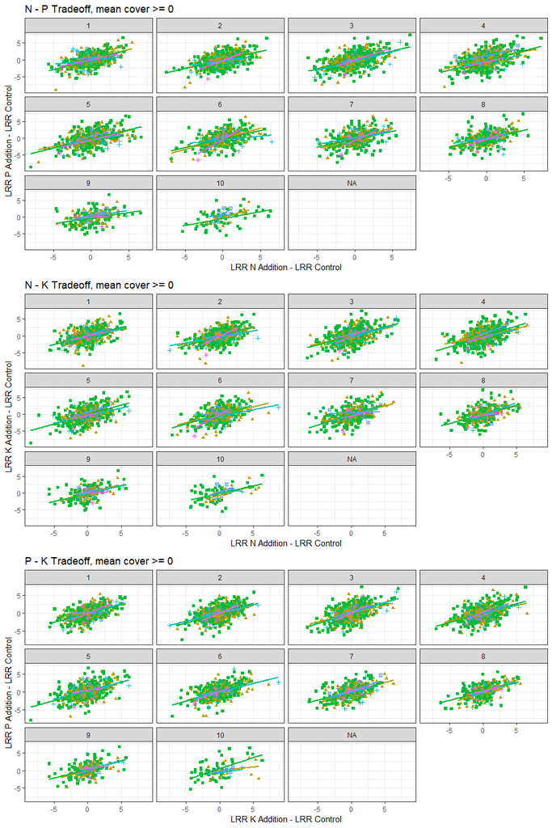

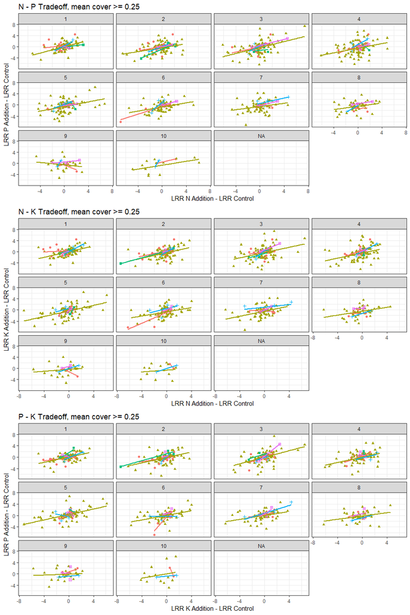

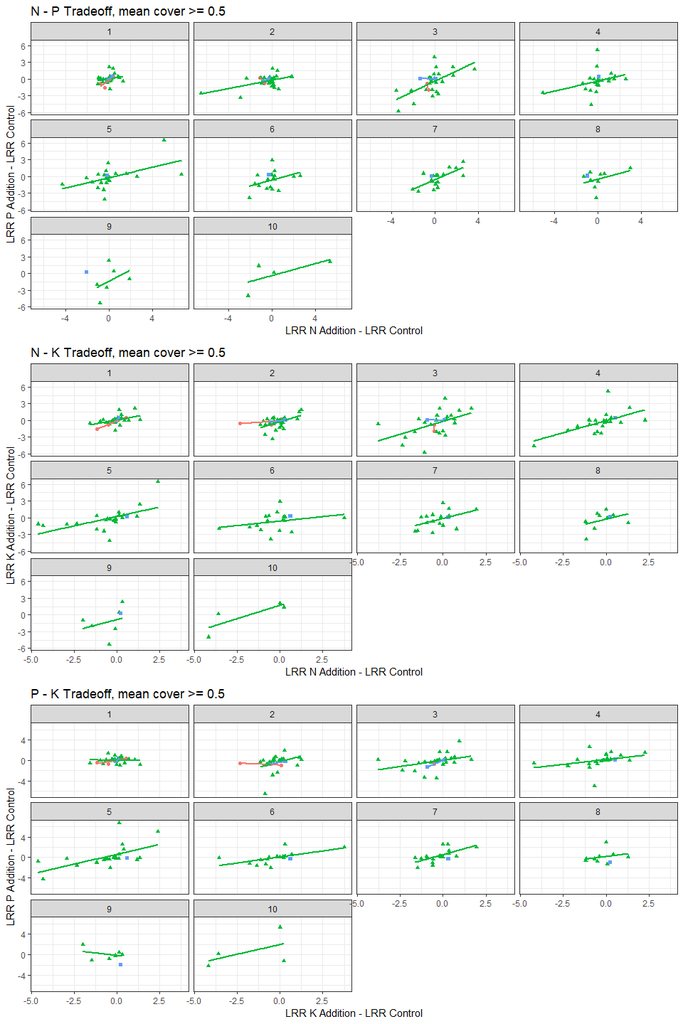

```r
tuning_LRRs <- function(meancov = .05,
                     persistence = .2,
                     initrep = 4){

  toselect = tuningtable %>% filter(
    mean_covControl >= meancov &
    (tot_obsControl / (lastyear - firstyear + 1)) >= persistence &
    pret_obsControl + pret_obsN + pret_obsP + pret_obsK >= initrep &
    pret_obsControl == 1) %>%
    select(site_code, block, Taxon, nyears)
  return(toselect)
}
for(mc in seq(0, .5, by = .25)){
  p1 = tuning_LRRs(meancov = mc, persistence = .2) %>% left_join(coef.npk.t) %>%
    ggplot(aes(y=LRR_N,x=LRR_P,color=functional_group,shape=functional_group,nyears)) +
    geom_point() + geom_smooth(method='lm', se=F) +
    facet_wrap(~year_trt) +
    #geom_hline(yintercept=-1,linetype='dashed') + geom_vline(xintercept=-1,linetype='dashed') +
    #geom_hline(yintercept=1,linetype='dashed') + geom_vline(xintercept=1,linetype='dashed') +
    theme_bw() + labs(x='LRR N Addition - LRR Control',y='LRR P Addition - LRR Control') +
    guides(shape = FALSE, color = FALSE) +
    ggtitle(paste("N - P Tradeoff, mean cover >=", mc))

  p2 = tuning_LRRs(meancov = mc, persistence = .2) %>% left_join(coef.npk.t) %>%
    ggplot(aes(y=LRR_N,x=LRR_K,color=functional_group,shape=functional_group,nyears)) +
    geom_point() + geom_smooth(method='lm', se=F) +
    facet_wrap(~year_trt) +
    #geom_hline(yintercept=-1,linetype='dashed') + geom_vline(xintercept=-1,linetype='dashed') +
    #geom_hline(yintercept=1,linetype='dashed') + geom_vline(xintercept=1,linetype='dashed') +
    theme_bw() + labs(x='LRR N Addition - LRR Control',y='LRR K Addition - LRR Control') +
    guides(shape = FALSE, color = FALSE)+
    ggtitle(paste("N - K Tradeoff, mean cover >=", mc))
    #theme(legend.position='bottom')

  p3 = tuning_LRRs(meancov = mc, persistence = .2) %>% left_join(coef.npk.t) %>%
    ggplot(aes(y=LRR_P,x=LRR_K,color=functional_group,shape=functional_group,nyears)) +
    geom_point() + geom_smooth(method='lm', se=F) +
    facet_wrap(~year_trt) +
    #geom_hline(yintercept=-1,linetype='dashed') + geom_vline(xintercept=-1,linetype='dashed') +
    #geom_hline(yintercept=1,linetype='dashed') + geom_vline(xintercept=1,linetype='dashed') +
    theme_bw() + labs(x='LRR K Addition - LRR Control',y='LRR P Addition - LRR Control') +
    guides(shape = FALSE, color = FALSE)+
    ggtitle(paste("P - K Tradeoff, mean cover >=", mc))

  grid.arrange(p1, p2, p3, nrow = 3)
}
```

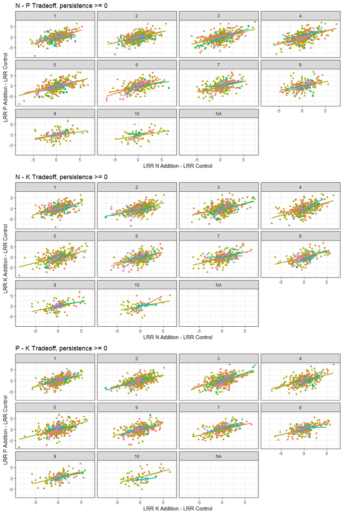

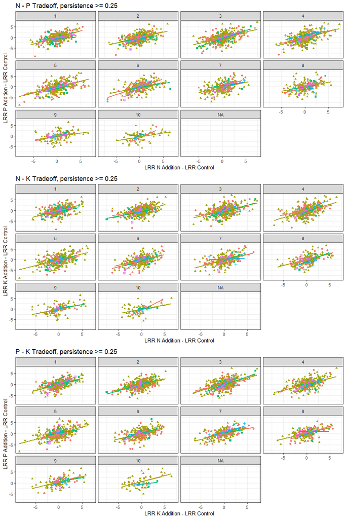

```r
for(pers in seq(0, .5, by = .25)){
  p1 = tuning_LRRs(meancov = .05, persistence = pers) %>% left_join(coef.npk.t) %>%
    ggplot(aes(y=LRR_N,x=LRR_P,color=functional_group,shape=functional_group,nyears)) +
    geom_point() + geom_smooth(method='lm', se=F) +
    facet_wrap(~year_trt) +
    #geom_hline(yintercept=-1,linetype='dashed') + geom_vline(xintercept=-1,linetype='dashed') +
    #geom_hline(yintercept=1,linetype='dashed') + geom_vline(xintercept=1,linetype='dashed') +
    theme_bw() + labs(x='LRR N Addition - LRR Control',y='LRR P Addition - LRR Control') +
    guides(shape = FALSE, color = FALSE) +
    ggtitle(paste("N - P Tradeoff, persistence >=", pers))

  p2 = tuning_LRRs(meancov = .05, persistence = pers) %>% left_join(coef.npk.t) %>%
    ggplot(aes(y=LRR_N,x=LRR_K,color=functional_group,shape=functional_group,nyears)) +
    geom_point() + geom_smooth(method='lm', se=F) +
    facet_wrap(~year_trt) +
    #geom_hline(yintercept=-1,linetype='dashed') + geom_vline(xintercept=-1,linetype='dashed') +
    #geom_hline(yintercept=1,linetype='dashed') + geom_vline(xintercept=1,linetype='dashed') +
    theme_bw() + labs(x='LRR N Addition - LRR Control',y='LRR K Addition - LRR Control') +
    guides(shape = FALSE, color = FALSE)+
    ggtitle(paste("N - K Tradeoff, persistence >=", pers))
    #theme(legend.position='bottom')

  p3 = tuning_LRRs(meancov = .05, persistence = pers) %>% left_join(coef.npk.t) %>%
    ggplot(aes(y=LRR_P,x=LRR_K,color=functional_group,shape=functional_group,nyears)) +
    geom_point() + geom_smooth(method='lm', se=F) +
    facet_wrap(~year_trt) +
    #geom_hline(yintercept=-1,linetype='dashed') + geom_vline(xintercept=-1,linetype='dashed') +
    #geom_hline(yintercept=1,linetype='dashed') + geom_vline(xintercept=1,linetype='dashed') +
    theme_bw() + labs(x='LRR K Addition - LRR Control',y='LRR P Addition - LRR Control') +
    guides(shape = FALSE, color = FALSE)+
    ggtitle(paste("P - K Tradeoff, persistence >=", pers))

  grid.arrange(p1, p2, p3, nrow = 3)
}
```

[output not shown]

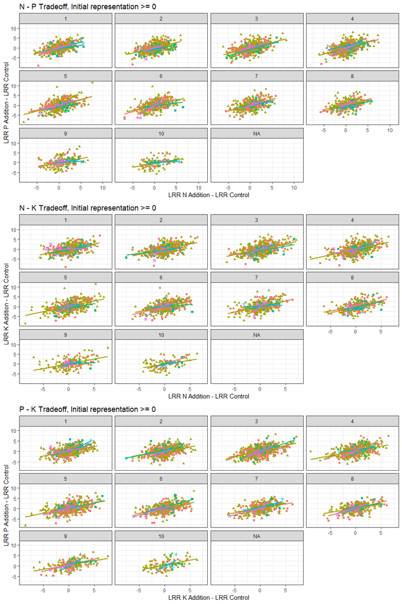

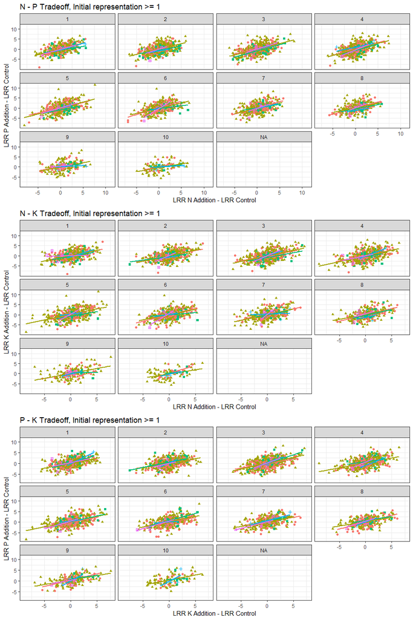

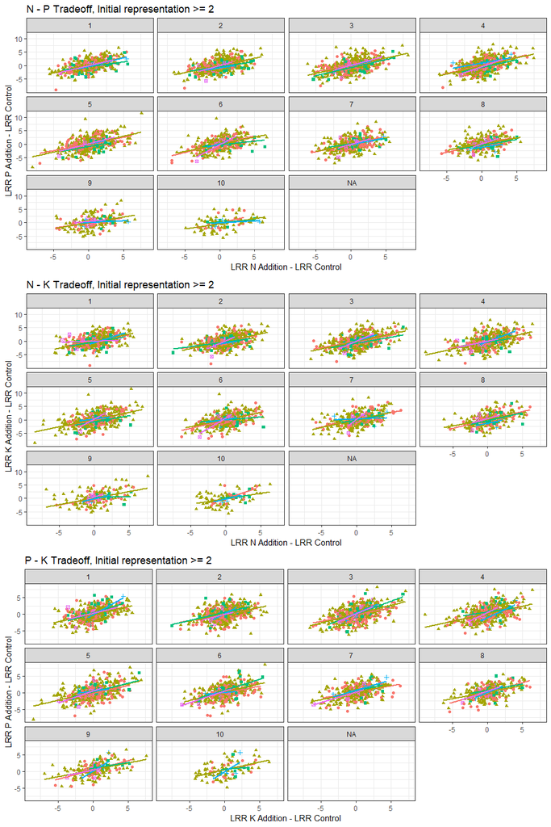

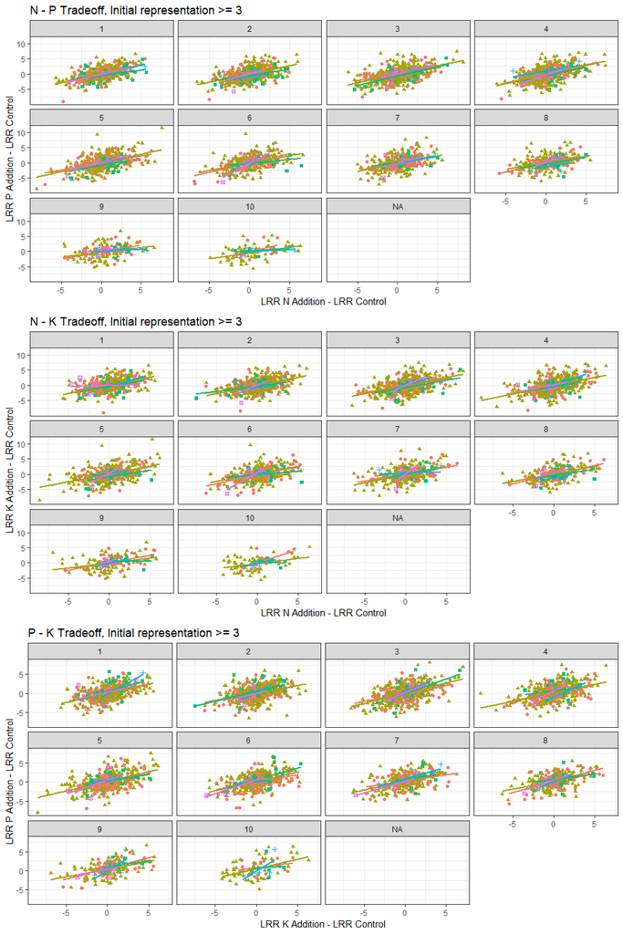

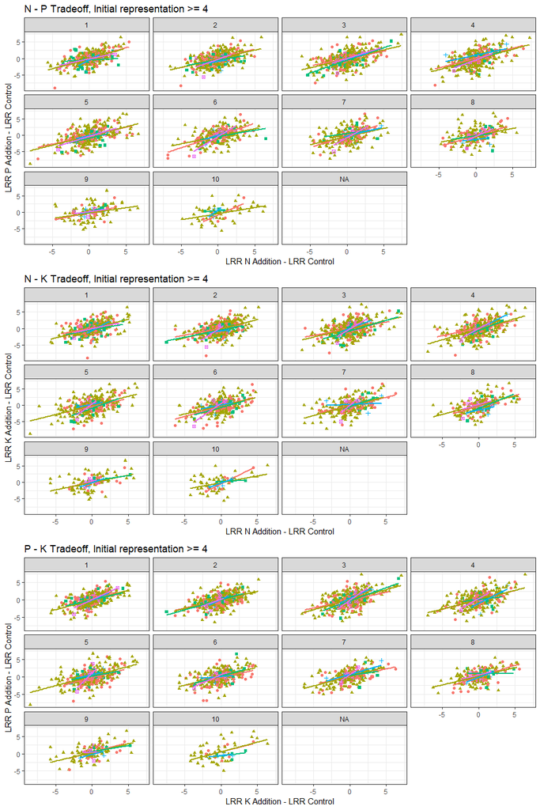

```r
for(initrep in seq(0, 4, by = 1)){
  p1 = tuning_LRRs(meancov = .05, persistence = .2, initrep = initrep) %>% left_join(coef.npk.t) %>%
    ggplot(aes(y=LRR_N,x=LRR_P,color=functional_group,shape=functional_group,nyears)) +
    geom_point() + geom_smooth(method='lm', se=F) +
    facet_wrap(~year_trt) +
    #geom_hline(yintercept=-1,linetype='dashed') + geom_vline(xintercept=-1,linetype='dashed') +
    #geom_hline(yintercept=1,linetype='dashed') + geom_vline(xintercept=1,linetype='dashed') +
    theme_bw() + labs(x='LRR N Addition - LRR Control',y='LRR P Addition - LRR Control') +
    guides(shape = FALSE, color = FALSE) +
    ggtitle(paste("N - P Tradeoff, Initial representation >=", initrep))

  p2 = tuning_LRRs(meancov = .05, persistence = .2, initrep = initrep) %>% left_join(coef.npk.t) %>%
    ggplot(aes(y=LRR_N,x=LRR_K,color=functional_group,shape=functional_group,nyears)) +
    geom_point() + geom_smooth(method='lm', se=F) +
    facet_wrap(~year_trt) +
    #geom_hline(yintercept=-1,linetype='dashed') + geom_vline(xintercept=-1,linetype='dashed') +
    #geom_hline(yintercept=1,linetype='dashed') + geom_vline(xintercept=1,linetype='dashed') +
    theme_bw() + labs(x='LRR N Addition - LRR Control',y='LRR K Addition - LRR Control') +
    guides(shape = FALSE, color = FALSE)+
    ggtitle(paste("N - K Tradeoff, Initial representation >=", initrep))
    #theme(legend.position='bottom')

  p3 =tuning_LRRs(meancov = .05, persistence = .2, initrep = initrep) %>% left_join(coef.npk.t) %>%
    ggplot(aes(y=LRR_P,x=LRR_K,color=functional_group,shape=functional_group,nyears)) +
    geom_point() + geom_smooth(method='lm', se=F) +
    facet_wrap(~year_trt) +
    #geom_hline(yintercept=-1,linetype='dashed') + geom_vline(xintercept=-1,linetype='dashed') +
    #geom_hline(yintercept=1,linetype='dashed') + geom_vline(xintercept=1,linetype='dashed') +
    theme_bw() + labs(x='LRR K Addition - LRR Control',y='LRR P Addition - LRR Control') +
    guides(shape = FALSE, color = FALSE)+
    ggtitle(paste("P - K Tradeoff, Initial representation >=", initrep))

  grid.arrange(p1, p2, p3, nrow = 3)
}
```